# 주분 3주차 패키지 과제 김지현

```python
import pandas as pd
import numpy as np

import matplotlib.pyplot as plt
import seaborn as sns

from category_encoders.cat_boost import CatBoostEncoder
import lightgbm as lgb
from lightgbm import LGBMModel,LGBMRegressor
```

```python
train = pd.read_csv("C:/Users/82105/OneDrive/바탕 화면/피셋/주제분석 3주차 패키지/train.csv")
test = pd.read_csv("C:/Users/82105/OneDrive/바탕 화면/피셋/주제분석 3주차 패키지/train.csv")


train_x = train.drop(['price'], axis = 1)
train_y = train.loc[:, ['price']]
test_x = test.drop(['price'], axis = 1)
test_y = np.sqrt(test.loc[:, ['price']])

feature_list = list(train_x.columns)

CBE_encoder = CatBoostEncoder()
train_cbe = CBE_encoder.fit_transform(train_x[feature_list], train_y)
test_cbe = CBE_encoder.transform(test_x[feature_list])

best_lgbm_reg = LGBMRegressor(learning_rate = 0.3)
best_lgbm_reg.fit(train_cbe, train_y)
```

```
LGBMRegressor(learning_rate=0.3)
```

```python
import pickle
import joblib

with open('C:/Users/82105/OneDrive/바탕 화면/피셋/주제분석 3주차 패키지/lgbm.pkl','rb') as fr:
    model = pickle.load(fr)
model
```

```
LGBMRegressor(learning_rate=0.3)
```

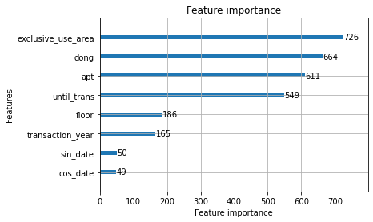

```python
from lightgbm import plot_importance
plot_importance(model)
```

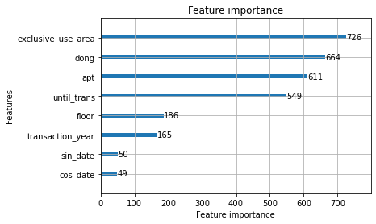

```python
from lightgbm import plot_importance
plot_importance(best_lgbm_reg)
```

```python
import random
import os
np.random.seed(42)
os.environ["PYTHONHASHSEED"] = str(42)
```

```python
from sklearn.inspection import permutation_importance
from matplotlib import pyplot
import requests
result=permutation_importance(best_lgbm_reg,test_cbe,test_y)
```

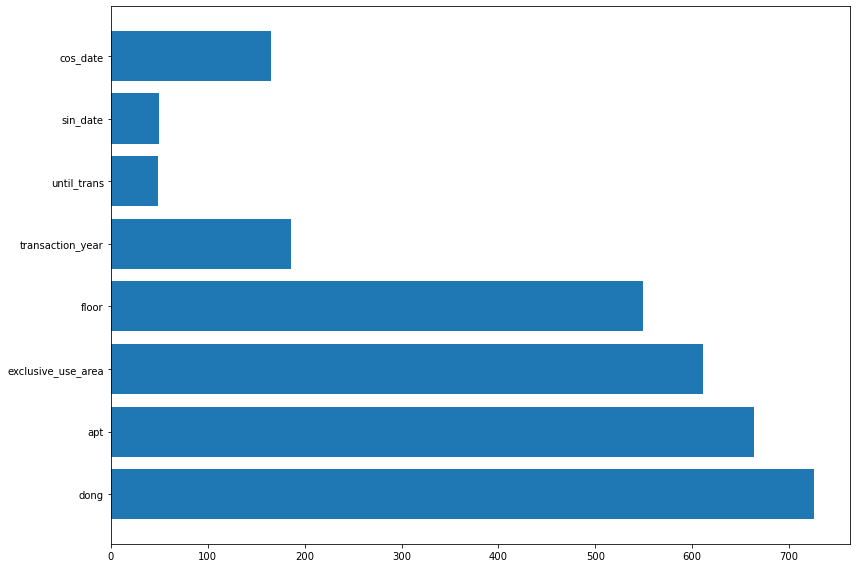

```python
perm_sorted_idx = result.importances_mean.argsort()

#tree_importance_sorted_idx = np.argsort(best_lgbm_reg.feature_importances_)
tree_indices = np.arange(0,len(best_lgbm_reg.feature_importances_))

fig, ax = plt.subplots(1,figsize=(12,8))
ax.barh(tree_indices,best_lgbm_reg.feature_importances_[perm_sorted_idx])
ax.set_yticks(tree_indices)
ax.set_yticklabels(test_x.columns.tolist())
fig.tight_layout()
plt.show()
```

처음한 방법:

sorted_idx = result.importances_mean.argsort()

```python
! pip install shap
```

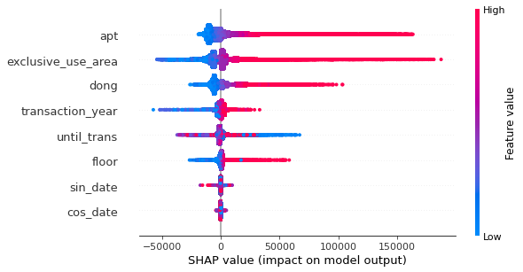

```python
import shap

feature_explain = shap.TreeExplainer(best_lgbm_reg)
shap_values = feature_explain.shap_values(test_cbe)
shap.summary_plot(shap_values,test_cbe)
```

2.딥러닝 기본

```python
train = pd.read_csv("C:/Users/82105/OneDrive/바탕 화면/피셋/주제분석 3주차 패키지/train.csv")
train_x = train.drop(['price'], axis = 1)
train_y = train.loc[:, ['price']]

val_x = train_x[train['transaction_year'] == 4]
val_y = train_y[train['transaction_year'] == 4]
train_tune_x = train_x[train['transaction_year'] < 4]
train_tune_y = train_y[train['transaction_year'] < 4]

CBE_encoder = CatBoostEncoder()
train_tune_cbe = CBE_encoder.fit_transform(train_tune_x[feature_list], train_tune_y)
val_cbe = CBE_encoder.transform(val_x[feature_list])
```

```python
!pip install keras
```

```python
import tensorflow as tf
import keras

from keras import models
from keras import layers
from keras.layers import Dense
from keras.optimizers import Adam
```

```python
def build_model():
  model = keras.Sequential([
    layers.Dense(256, activation='relu', input_shape=[len(train_tune_cbe.keys())]),
    layers.Dense(64, activation='relu'),
    layers.Dense(32, activation='relu'),
    layers.Dense(1)
  ])

  optimizer = tf.keras.optimizers.RMSprop(0.0001)

  model.compile(loss='mse',
                optimizer=optimizer,
                metrics=['mse'])
  return model
```

```python
model = build_model()
model.summary()
```

```
Model: "sequential"
_________________________________________________________________
Layer (type)                 Output Shape              Param #
=================================================================
dense (Dense)                (None, 256)               2304
_________________________________________________________________
dense_1 (Dense)              (None, 64)                16448
_________________________________________________________________
dense_2 (Dense)              (None, 32)                2080
_________________________________________________________________
dense_3 (Dense)              (None, 1)                 33
=================================================================
Total params: 20,865
Trainable params: 20,865
Non-trainable params: 0
_________________________________________________________________
```

주어진 모델은 Sequential 모델로, 각 레이어에 정확히 하나의 입력 텐서와 하나의 출력 텐서가 있는 일반 레이어 스택에 적합합니다.

2.2 training loss와 validation loss를 시각화하세요.

```python
history = model.fit(train_tune_cbe, train_tune_y, epochs=300, validation_data = (val_cbe, val_y), batch_size = 512)
```

```python
history.history.keys()
```

```
dict_keys(['loss', 'mse', 'val_loss', 'val_mse'])
```

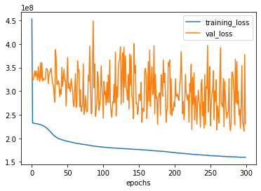

```python
training_loss = history.history['loss']
val_loss = history.history['val_loss']
plt.legend(['training_loss','val_loss'])
plt.plot(training_loss)

plt.plot(val_loss)
plt.legend(['training_loss','val_loss'])
plt.xlabel('epochs')
plt.show()
```

밑에 코드는 MSE까지 구하는 방법 구글링 통해서 알게 된 것. 나중에 참고만 하자.

```python
def vis(history,name) :
    plt.title(f"{name.upper()}")
    plt.xlabel('epochs')
    plt.ylabel(f"{name.lower()}")
    value = history.history.get(name)
    val_value = history.history.get(f"val_{name}",None)
    epochs = range(1, len(value)+1)
    plt.plot(epochs, value, 'b-', label=f'training {name}')
    if val_value is not None :
        plt.plot(epochs, val_value, 'r:', label=f'validation {name}')
    plt.legend(loc='upper center', bbox_to_anchor=(0.05, 1.2) , fontsize=10 , ncol=1)

def plot_history(history) :
    key_value = list(set([i.split("val_")[-1] for i in list(history.history.keys())]))
    plt.figure(figsize=(12, 4))
    for idx , key in enumerate(key_value) :
        plt.subplot(1, len(key_value), idx+1)
        vis(history, key)
    plt.tight_layout()
    plt.show()
```

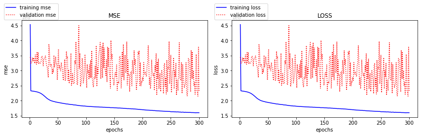

```python
plot_history(history)
```

2.4 더 좋은 성능의 딥러닝 모델을 위해 test set에 대해 딥러닝 모형의 성능을 평가하세요. dense 조절, batch_size 조절, regularization, dropout, batch normalization 등의 방법을 활용해 최고의 성능을 얻어보세요. 만약 성능의 향상이 어렵다면, 다양한 방법들을 시도하는 것을 목표로 해주세요!

```python
feature_list = list(train_x.columns)

CBE_encoder = CatBoostEncoder()
train_cbe = CBE_encoder.fit_transform(train_x[feature_list], train_y)
test_cbe = CBE_encoder.transform(test_x[feature_list])
```

```python
def build_model():
  model = keras.Sequential([
    layers.Dense(256, activation='relu', input_shape=[len(train_tune_cbe.keys())]),
    layers.Dense(64, activation='relu'),
    layers.Dense(32, activation='relu'),
    layers.Dense(1)
  ])

  optimizer = tf.keras.optimizers.RMSprop(0.0001)

  model.compile(loss='mse',
                optimizer=sgd,## optimizer를 바꿔봄
                metrics=['mse'])
  return model
```

```python
history = model.fit(train_tune_cbe, train_tune_y, epochs=300, validation_data = (val_cbe, val_y), batch_size = 256)
#batch_size 조절
```

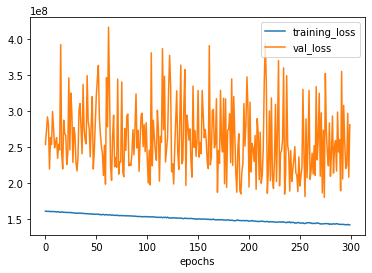

```python
training_loss = history.history['loss']
val_loss = history.history['val_loss']
plt.legend(['training_loss','val_loss'])
plt.plot(training_loss)

plt.plot(val_loss)
plt.legend(['training_loss','val_loss'])
plt.xlabel('epochs')
plt.show()
```